# Presentation slides

### 1. Info preliminari

Il dataset proviene da METABRIC. Dati raccolti dal professor Carlos Caldas e dal professor Sam Aparicio pubblicato su Nature Communications (Pereira et al., 2016)

### 2. Motivazione

Il cancro colpisce **2,1 milioni di donne ogni anno**. Solo nel 2018, si stima che **627.000** donne siano morte di cancro al seno.

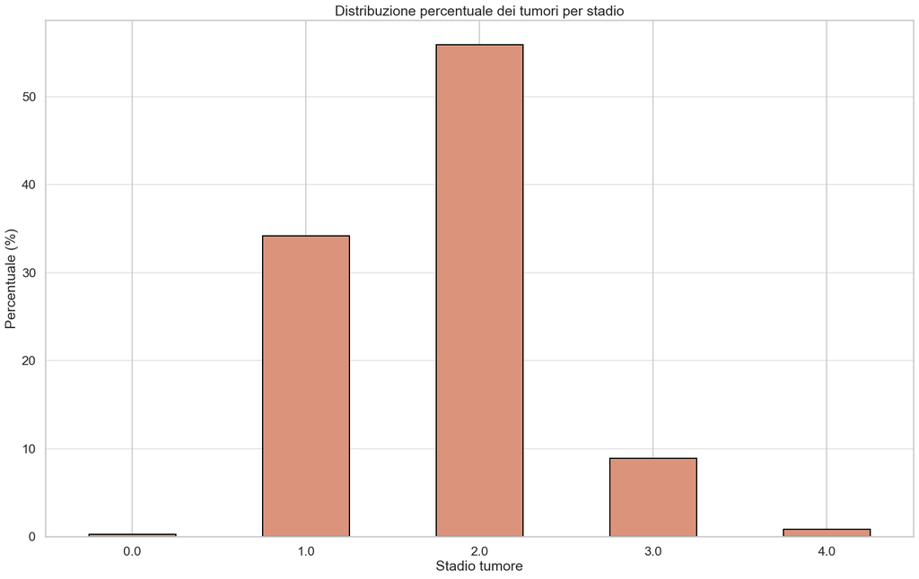

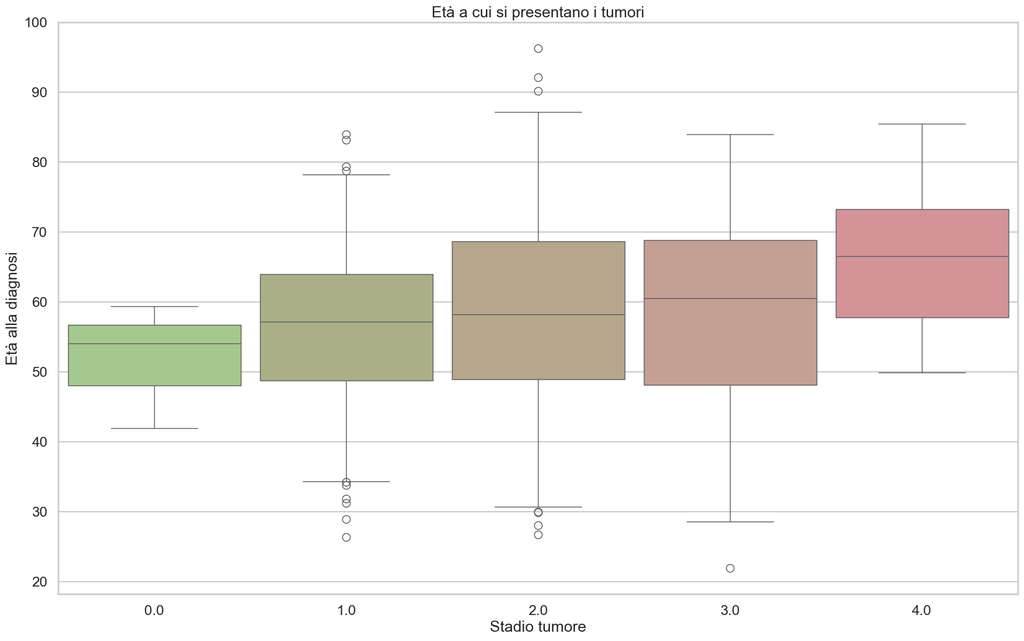

### **L'età influisce sulla possibilità di sopravvivenza?**

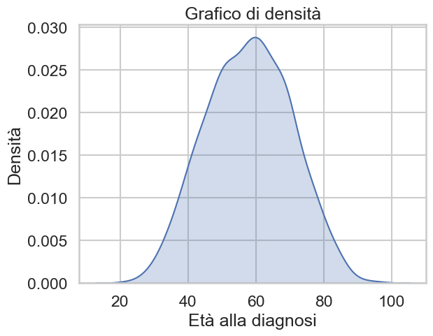

```
L'età media dei pazienti affetti da cancro al seno è di: 57.9 anni
```

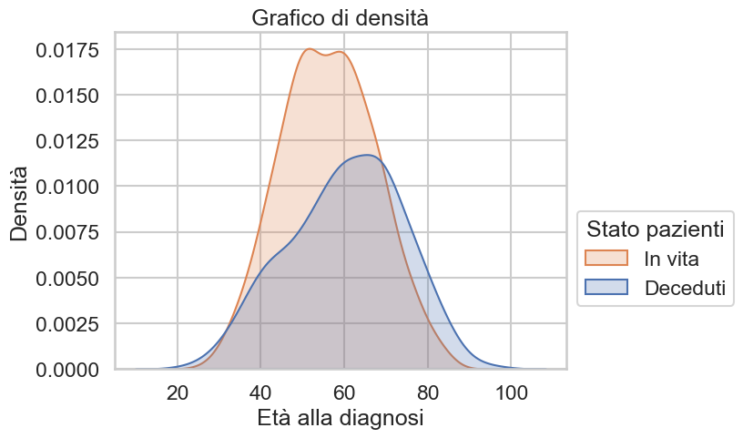

**Le terapie e la mastectomia influiscono sulla mortalità?**

```
I numeri al di sopra di ogni barra rappresentano le quantità assolute
```

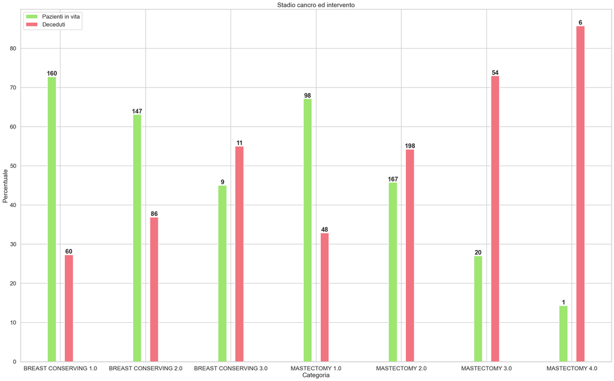

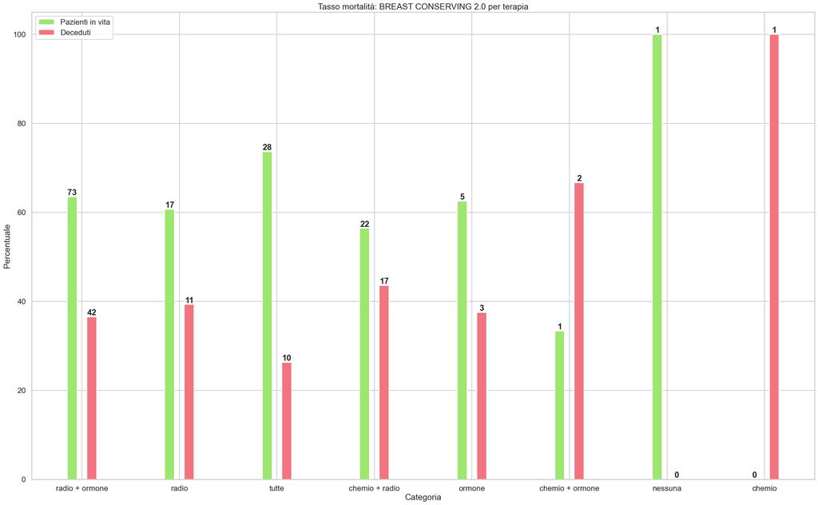

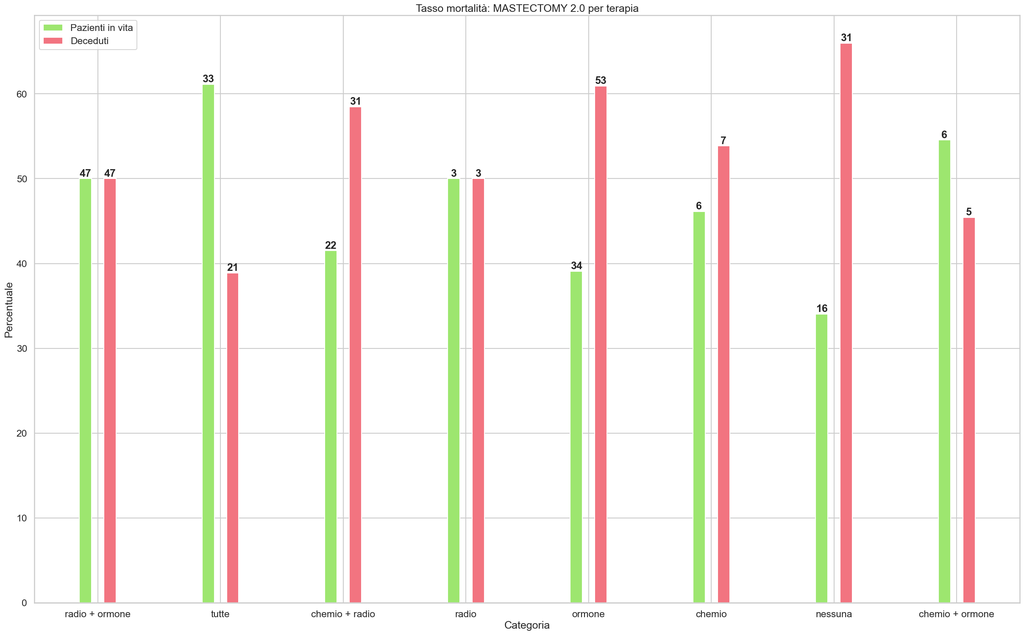

**Quali sono le cure più diffuse?**

Consideriamo solo i dati di pazienti in vita

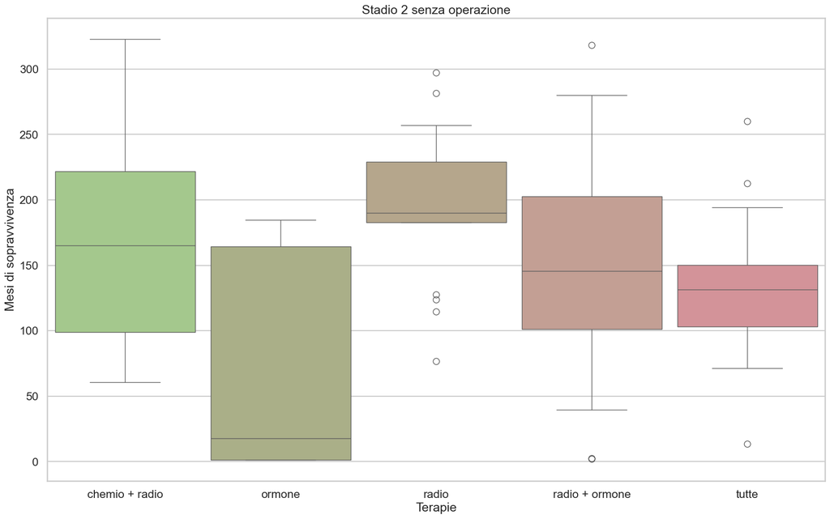

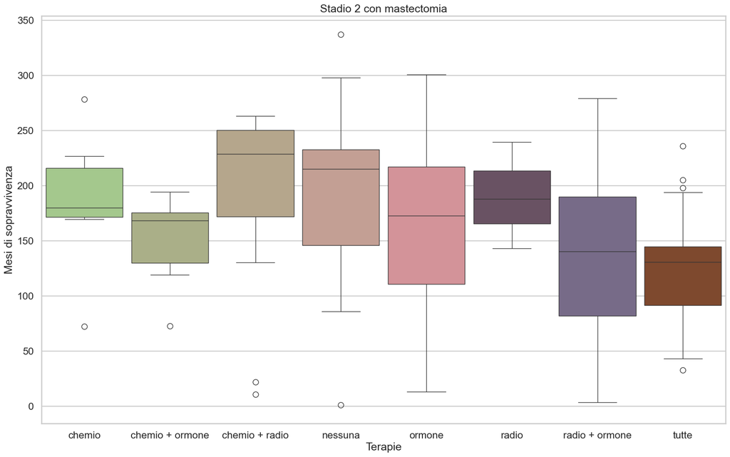

**Conclusioni**

**Prevenzione** Prima viene diagnosticato un tumore e più possibilità ci sono che sia piccolo.

**Tempo di cura stadio 2:**

1. I pazienti senza operazione: mediamente tra i 50 ed i 200 mesi (4-17 anni)
2. I pazienti con operazione: mediamente tra i 100 ed i 250 mesi (8-21 anni)

**Premessa** Non essendo esperto di dominio, ho preso in considerazione solo alcune colonne del dataset

##### Caratteristiche dataset

| **Name** | **Type** | **Description** |
| --- | --- | --- |
| patient_id | object | ID Paziente |
| age_at_diagnosis | float | Età del paziente al momento della diagnosi |
| type_of_breast_surgery | object | 1- mastectomia 2- conservazione seno |
| chemotherapy | int | Se il paziente ha ricevuto la chemioterapia |
| hormone_therapy | int | Se il paziente ha ricevuto un trattamento ormonale |
| overall_survival_months | float | Durata dal momento dell'intervento fino al decesso |
| overall_survival | object | Se il paziente è vivo o deceduto. |
| tumor_size | float | Dimensioni del tumore |
| tumor_stage | float | Stadio del cancro |
| death_from_cancer | int | Se la morte del paziente è stata dovuta al cancro |

##### Ringraziamenti

Set di dati sul cancro al seno (METABRIC, Nature 2012 e Nat Commun 2016) in CBioPortal Studio METABRIC Cerami et al. The cBio Cancer Genomics Portal: una piattaforma aperta per esplorare dati di genomica del cancro multidimensionale. Cancer Discovery. Maggio 2012 2. Gao et al. Analisi integrativa di profili clinici e genomica del cancro complessi utilizzando cBioPortal. Sci. Signal. 6, pl1 (2013).